# Project: Investigate TMBD Movie Data

- Introduction
- Data Wrangling
- Exploratory Data Analysis
- Conclusions

## Introduction

> For this Data Analyst project, I selected the TMDb movie dataset from kaggle to investigate. According to kaggle introduction page, the data contains information that are provided from The Movie Database (TMDb). It collects 5000+ movies and their rating and basic move information, including user ratings and revenue data.

### Metrics for Evaluating the Success Movie

How much REVENUE was generated

The POPULARITY it gained

The average VOTE SCORED

### Potential Key to Affect the Success of a Movie

Budget

Cast

Director

Tagline

Keywords

Runtime

Genres

Production Companies

Release Date

Vote Average

> Since the dataset is featured with the rating of movies as mentioned above, it contains plentiful information for exploring the properties that are associated with successful movies, which can be defined by high popularity, high revenue and high rating score movies. Besides, the dataset also contains the movie released year, so it also can let us to explore the trend in these movie metrics. Therefore, the qestions I am going to explore are including three parts:

### General Characteristics

Question 1: Popularity Over Years

Question 2: The distribution of revenue in different popularity levels in recent five years.

Question 3: The distribution of revenue in different score rating levels in recent five years.

```python
# Use this cell to set up import statements for all of the packages that you
#   plan to use.
# Import statements for all of the packages that I plan to use.

import pandas as pd
import numpy as np
import matplotlib.pyplot as plt
import seaborn as sns
from collections import Counter
% matplotlib inline

# Remember to include a 'magic word' so that your visualizations are plotted
#   inline with the notebook. See this page for more:
#   http://ipython.readthedocs.io/en/stable/interactive/magics.html
```

```python
# Upgrade pandas to use dataframe.explode() function, which I did.
!pip install --upgrade pandas==0.25.0
```

### Data Wrangling

```python
# Load your data and print out a few lines. Perform operations to inspect data
# types and look for instances of missing or possibly errant data.
df = pd.read_csv('tmdb-movies.csv')
df.head()
```

|  | id | imdb_id | popularity | budget | revenue | original_title | cast | homepage | director | tagline | ... | overview | runtime | genres | production_companies | release_date | vote_count | vote_average | release_year | budget_adj | revenue_adj |
| --- | --- | --- | --- | --- | --- | --- | --- | --- | --- | --- | --- | --- | --- | --- | --- | --- | --- | --- | --- | --- | --- |
| 0 | 135397 | tt0369610 | 32.985763 | 150000000 | 1513528810 | Jurassic World | Chris Pratt\|Bryce Dallas Howard\|Irrfan Khan\|Vi... | http://www.jurassicworld.com/ | Colin Trevorrow | The park is open. | ... | Twenty-two years after the events of Jurassic ... | 124 | Action\|Adventure\|Science Fiction\|Thriller | Universal Studios\|Amblin Entertainment\|Legenda... | 6/9/15 | 5562 | 6.5 | 2015 | 1.379999e+08 | 1.392446e+09 |
| 1 | 76341 | tt1392190 | 28.419936 | 150000000 | 378436354 | Mad Max: Fury Road | Tom Hardy\|Charlize Theron\|Hugh Keays-Byrne\|Nic... | http://www.madmaxmovie.com/ | George Miller | What a Lovely Day. | ... | An apocalyptic story set in the furthest reach... | 120 | Action\|Adventure\|Science Fiction\|Thriller | Village Roadshow Pictures\|Kennedy Miller Produ... | 5/13/15 | 6185 | 7.1 | 2015 | 1.379999e+08 | 3.481613e+08 |
| 2 | 262500 | tt2908446 | 13.112507 | 110000000 | 295238201 | Insurgent | Shailene Woodley\|Theo James\|Kate Winslet\|Ansel... | http://www.thedivergentseries.movie/#insurgent | Robert Schwentke | One Choice Can Destroy You | ... | Beatrice Prior must confront her inner demons ... | 119 | Adventure\|Science Fiction\|Thriller | Summit Entertainment\|Mandeville Films\|Red Wago... | 3/18/15 | 2480 | 6.3 | 2015 | 1.012000e+08 | 2.716190e+08 |
| 3 | 140607 | tt2488496 | 11.173104 | 200000000 | 2068178225 | Star Wars: The Force Awakens | Harrison Ford\|Mark Hamill\|Carrie Fisher\|Adam D... | http://www.starwars.com/films/star-wars-episod... | J.J. Abrams | Every generation has a story. | ... | Thirty years after defeating the Galactic Empi... | 136 | Action\|Adventure\|Science Fiction\|Fantasy | Lucasfilm\|Truenorth Productions\|Bad Robot | 12/15/15 | 5292 | 7.5 | 2015 | 1.839999e+08 | 1.902723e+09 |
| 4 | 168259 | tt2820852 | 9.335014 | 190000000 | 1506249360 | Furious 7 | Vin Diesel\|Paul Walker\|Jason Statham\|Michelle ... | http://www.furious7.com/ | James Wan | Vengeance Hits Home | ... | Deckard Shaw seeks revenge against Dominic Tor... | 137 | Action\|Crime\|Thriller | Universal Pictures\|Original Film\|Media Rights ... | 4/1/15 | 2947 | 7.3 | 2015 | 1.747999e+08 | 1.385749e+09 |

5 rows × 21 columns

```python
# Checking the data info and null values
df.info()
```

```
<class 'pandas.core.frame.DataFrame'>
RangeIndex: 10866 entries, 0 to 10865
Data columns (total 21 columns):
id                      10866 non-null int64
imdb_id                 10856 non-null object
popularity              10866 non-null float64
budget                  10866 non-null int64
revenue                 10866 non-null int64
original_title          10866 non-null object
cast                    10790 non-null object
homepage                2936 non-null object
director                10822 non-null object
tagline                 8042 non-null object
keywords                9373 non-null object
overview                10862 non-null object
runtime                 10866 non-null int64
genres                  10843 non-null object
production_companies    9836 non-null object
release_date            10866 non-null object
vote_count              10866 non-null int64
vote_average            10866 non-null float64
release_year            10866 non-null int64
budget_adj              10866 non-null float64
revenue_adj             10866 non-null float64
dtypes: float64(4), int64(6), object(11)
memory usage: 1.7+ MB
```

The table above shows that, the dataset contains:

10866 entries and total

21 columns.

Null values in: Cast, Director, Overview, Genres_columns, Homepage, Tagline, Keywords and Production_companies.

Two columns with too much null values (i.e.Homepage and Tagline) were dropped as they don't add much to asnwering the questions.

```python
df.describe()
```

|  | id | popularity | budget | revenue | runtime | vote_count | vote_average | release_year | budget_adj | revenue_adj |
| --- | --- | --- | --- | --- | --- | --- | --- | --- | --- | --- |
| count | 10866.000000 | 10866.000000 | 1.086600e+04 | 1.086600e+04 | 10866.000000 | 10866.000000 | 10866.000000 | 10866.000000 | 1.086600e+04 | 1.086600e+04 |
| mean | 66064.177434 | 0.646441 | 1.462570e+07 | 3.982332e+07 | 102.070863 | 217.389748 | 5.974922 | 2001.322658 | 1.755104e+07 | 5.136436e+07 |
| std | 92130.136561 | 1.000185 | 3.091321e+07 | 1.170035e+08 | 31.381405 | 575.619058 | 0.935142 | 12.812941 | 3.430616e+07 | 1.446325e+08 |
| min | 5.000000 | 0.000065 | 0.000000e+00 | 0.000000e+00 | 0.000000 | 10.000000 | 1.500000 | 1960.000000 | 0.000000e+00 | 0.000000e+00 |
| 25% | 10596.250000 | 0.207583 | 0.000000e+00 | 0.000000e+00 | 90.000000 | 17.000000 | 5.400000 | 1995.000000 | 0.000000e+00 | 0.000000e+00 |
| 50% | 20669.000000 | 0.383856 | 0.000000e+00 | 0.000000e+00 | 99.000000 | 38.000000 | 6.000000 | 2006.000000 | 0.000000e+00 | 0.000000e+00 |
| 75% | 75610.000000 | 0.713817 | 1.500000e+07 | 2.400000e+07 | 111.000000 | 145.750000 | 6.600000 | 2011.000000 | 2.085325e+07 | 3.369710e+07 |
| max | 417859.000000 | 32.985763 | 4.250000e+08 | 2.781506e+09 | 900.000000 | 9767.000000 | 9.200000 | 2015.000000 | 4.250000e+08 | 2.827124e+09 |

```python
#to filter the zero budget data
df_budget_zero = df.query('budget == 0')
df_budget_zero.head(2)
```

|  | id | imdb_id | popularity | budget | revenue | original_title | cast | homepage | director | tagline | ... | overview | runtime | genres | production_companies | release_date | vote_count | vote_average | release_year | budget_adj | revenue_adj |
| --- | --- | --- | --- | --- | --- | --- | --- | --- | --- | --- | --- | --- | --- | --- | --- | --- | --- | --- | --- | --- | --- |
| 30 | 280996 | tt3168230 | 3.927333 | 0 | 29355203 | Mr. Holmes | Ian McKellen\|Milo Parker\|Laura Linney\|Hattie M... | http://www.mrholmesfilm.com/ | Bill Condon | The man behind the myth | ... | The story is set in 1947, following a long-ret... | 103 | Mystery\|Drama | BBC Films\|See-Saw Films\|FilmNation Entertainme... | 6/19/15 | 425 | 6.4 | 2015 | 0.0 | 2.700677e+07 |
| 36 | 339527 | tt1291570 | 3.358321 | 0 | 22354572 | Solace | Abbie Cornish\|Jeffrey Dean Morgan\|Colin Farrel... | NaN | Afonso Poyart | A serial killer who can see your future, a psy... | ... | A psychic doctor, John Clancy, works with an F... | 101 | Crime\|Drama\|Mystery | Eden Rock Media\|FilmNation Entertainment\|Flynn... | 9/3/15 | 474 | 6.2 | 2015 | 0.0 | 2.056620e+07 |

2 rows × 21 columns

```python
#to filter the zero revenue data
df_revenue_zero = df.query('revenue == 0')
df_revenue_zero.head(2)
```

|  | id | imdb_id | popularity | budget | revenue | original_title | cast | homepage | director | tagline | ... | overview | runtime | genres | production_companies | release_date | vote_count | vote_average | release_year | budget_adj | revenue_adj |
| --- | --- | --- | --- | --- | --- | --- | --- | --- | --- | --- | --- | --- | --- | --- | --- | --- | --- | --- | --- | --- | --- |
| 48 | 265208 | tt2231253 | 2.932340 | 30000000 | 0 | Wild Card | Jason Statham\|Michael Angarano\|Milo Ventimigli... | NaN | Simon West | Never bet against a man with a killer hand. | ... | When a Las Vegas bodyguard with lethal skills ... | 92 | Thriller\|Crime\|Drama | Current Entertainment\|Lionsgate\|Sierra / Affin... | 1/14/15 | 481 | 5.3 | 2015 | 2.759999e+07 | 0.0 |
| 67 | 334074 | tt3247714 | 2.331636 | 20000000 | 0 | Survivor | Pierce Brosnan\|Milla Jovovich\|Dylan McDermott\|... | http://survivormovie.com/ | James McTeigue | His Next Target is Now Hunting Him | ... | A Foreign Service Officer in London tries to p... | 96 | Crime\|Thriller\|Action | Nu Image Films\|Winkler Films\|Millennium Films\|... | 5/21/15 | 280 | 5.4 | 2015 | 1.839999e+07 | 0.0 |

2 rows × 21 columns

```python
#to count zero values in budget data
df_budget_0count =  df.groupby('budget').count()['id']
df_budget_0count.head(2)
```

```
budget
0    5696
1       4
Name: id, dtype: int64
```

```python
#to count zero values in revenue data
df_revenue_0count =  df.groupby('revenue').count()['id']
df_revenue_0count.head(2)
```

```
revenue
0    6016
2       2
Name: id, dtype: int64
```

```python
#to count zero values in runtime data
df_runtime_0count =  df.groupby('runtime').count()['id']
df_runtime_0count.head(2)
```

```
runtime
0    31
2     5
Name: id, dtype: int64
```

### Data Cleaning

Columns with duplicate values will be dropped too.

Columns with null values are also dropped: cast, director, and genres

Columns with zero values are replaced with null values: budget and revenue.

```python
# Dropping the unncessary columns: imdb_id, homepage, tagline, overview, budget_adj, revenue_adj
col = ['imdb_id', 'homepage', 'tagline', 'overview', 'budget_adj', 'revenue_adj']
df.drop(col, axis=1, inplace=True)
```

```python
# Checking the dropped columns
df.head(1)
```

|  | id | popularity | budget | revenue | original_title | cast | director | keywords | runtime | genres | production_companies | release_date | vote_count | vote_average | release_year |
| --- | --- | --- | --- | --- | --- | --- | --- | --- | --- | --- | --- | --- | --- | --- | --- |
| 0 | 135397 | 32.985763 | 150000000 | 1513528810 | Jurassic World | Chris Pratt\|Bryce Dallas Howard\|Irrfan Khan\|Vi... | Colin Trevorrow | monster\|dna\|tyrannosaurus rex\|velociraptor\|island | 124 | Action\|Adventure\|Science Fiction\|Thriller | Universal Studios\|Amblin Entertainment\|Legenda... | 6/9/15 | 5562 | 6.5 | 2015 |

```python
#Dropping duplicates
df.drop_duplicates(inplace=True)
```

```python
#Dropping null values in: cast, director, genres
cal2 = ['cast', 'director', 'genres']
df.dropna(subset = cal2, how='any', inplace=True)
df.isnull().sum()
```

```
id                         0
popularity                 0
budget                     0
revenue                    0
original_title             0
cast                       0
director                   0
keywords                1425
runtime                    0
genres                     0
production_companies     959
release_date               0
vote_count                 0
vote_average               0
release_year               0
dtype: int64
```

```python
#Replacing zero values with null values: budget and revenue
df['budget'] = df['budget'].replace(0, np.NaN)
df['revenue'] = df['revenue'].replace(0, np.NaN)
df.info()
```

```
<class 'pandas.core.frame.DataFrame'>
Int64Index: 10731 entries, 0 to 10865
Data columns (total 15 columns):
id                      10731 non-null int64
popularity              10731 non-null float64
budget                  5153 non-null float64
revenue                 4843 non-null float64
original_title          10731 non-null object
cast                    10731 non-null object
director                10731 non-null object
keywords                9306 non-null object
runtime                 10731 non-null int64
genres                  10731 non-null object
production_companies    9772 non-null object
release_date            10731 non-null object
vote_count              10731 non-null int64
vote_average            10731 non-null float64
release_year            10731 non-null int64
dtypes: float64(4), int64(4), object(7)
memory usage: 1.3+ MB
```

```python
#Filtering the runtime data with non_zero value
df.query('runtime != 0', inplace=True)
df.query('runtime == 0')
```

|  | id | popularity | budget | revenue | original_title | cast | director | keywords | runtime | genres | production_companies | release_date | vote_count | vote_average | release_year |
| --- | --- | --- | --- | --- | --- | --- | --- | --- | --- | --- | --- | --- | --- | --- | --- |

#### Cleaned Dataset

```python
df.info()
df.describe()
```

```
<class 'pandas.core.frame.DataFrame'>
Int64Index: 10703 entries, 0 to 10865
Data columns (total 15 columns):
id                      10703 non-null int64
popularity              10703 non-null float64
budget                  5150 non-null float64
revenue                 4843 non-null float64
original_title          10703 non-null object
cast                    10703 non-null object
director                10703 non-null object
keywords                9293 non-null object
runtime                 10703 non-null int64
genres                  10703 non-null object
production_companies    9759 non-null object
release_date            10703 non-null object
vote_count              10703 non-null int64
vote_average            10703 non-null float64
release_year            10703 non-null int64
dtypes: float64(4), int64(4), object(7)
memory usage: 1.3+ MB
```

|  | id | popularity | budget | revenue | runtime | vote_count | vote_average | release_year |
| --- | --- | --- | --- | --- | --- | --- | --- | --- |
| count | 10703.000000 | 10703.000000 | 5.150000e+03 | 4.843000e+03 | 10703.000000 | 10703.000000 | 10703.000000 | 10703.000000 |
| mean | 64904.988321 | 0.653818 | 3.084401e+07 | 8.933981e+07 | 102.736896 | 220.333178 | 5.966112 | 2001.235355 |
| std | 91161.996308 | 1.005687 | 3.893782e+07 | 1.621546e+08 | 30.079331 | 579.481969 | 0.930155 | 12.825920 |
| min | 5.000000 | 0.000188 | 1.000000e+00 | 2.000000e+00 | 3.000000 | 10.000000 | 1.500000 | 1960.000000 |
| 25% | 10538.500000 | 0.211533 | 6.000000e+06 | 7.779664e+06 | 90.000000 | 17.000000 | 5.400000 | 1995.000000 |
| 50% | 20235.000000 | 0.388036 | 1.750000e+07 | 3.191160e+07 | 99.000000 | 39.000000 | 6.000000 | 2006.000000 |
| 75% | 73637.000000 | 0.722438 | 4.000000e+07 | 1.000000e+08 | 112.000000 | 149.000000 | 6.600000 | 2011.000000 |
| max | 417859.000000 | 32.985763 | 4.250000e+08 | 2.781506e+09 | 900.000000 | 9767.000000 | 9.200000 | 2015.000000 |

## Exploratory Data Analysis

Question 1: Popularity Over Years

Question 2: The distribution of revenue in different popularity levels in recent five years.

Question 3: The distribution of revenue in different score rating levels in recent five years.

### QUESTION 1

```python
df.head(2)
```

|  | id | popularity | budget | revenue | original_title | cast | director | keywords | runtime | genres | production_companies | release_date | vote_count | vote_average | release_year |
| --- | --- | --- | --- | --- | --- | --- | --- | --- | --- | --- | --- | --- | --- | --- | --- |
| 0 | 135397 | 32.985763 | 150000000.0 | 1.513529e+09 | Jurassic World | Chris Pratt\|Bryce Dallas Howard\|Irrfan Khan\|Vi... | Colin Trevorrow | monster\|dna\|tyrannosaurus rex\|velociraptor\|island | 124 | Action\|Adventure\|Science Fiction\|Thriller | Universal Studios\|Amblin Entertainment\|Legenda... | 6/9/15 | 5562 | 6.5 | 2015 |
| 1 | 76341 | 28.419936 | 150000000.0 | 3.784364e+08 | Mad Max: Fury Road | Tom Hardy\|Charlize Theron\|Hugh Keays-Byrne\|Nic... | George Miller | future\|chase\|post-apocalyptic\|dystopia\|australia | 120 | Action\|Adventure\|Science Fiction\|Thriller | Village Roadshow Pictures\|Kennedy Miller Produ... | 5/13/15 | 6185 | 7.1 | 2015 |

```python
#Computing the mean for popularity
p_mean = df.groupby('release_year').mean()['popularity']
p_mean.tail()
```

```
release_year
2011    0.685607
2012    0.620326
2013    0.639309
2014    0.910027
2015    1.055081
Name: popularity, dtype: float64
```

```python
# compute the median for popularity
p_median = df.groupby('release_year').median()['popularity']
p_median.tail()
```

```
release_year
2011    0.420930
2012    0.344263
2013    0.356506
2014    0.383337
2015    0.407396
Name: popularity, dtype: float64
```

Median values for popularity is more sequenced than for mean.

### QUESTION 2

It will be essential to build a cut_into_quantile function to have the data in four quartile: 'Little', 'Average', 'Much', 'Very Much'

```python
def cut_into_quantile(dfname ,column_name):
# Quartile maximum and minimum values
    min_value = dfname[column_name].min()
    first_quantile = dfname[column_name].describe()[4]
    second_quantile = dfname[column_name].describe()[5]
    third_quantile = dfname[column_name].describe()[6]
    max_value = dfname[column_name].max()
# Bin_edges to cut quartiles into groups
    bin_edges = [ min_value, first_quantile, second_quantile, third_quantile, max_value]
# The four levels
    bin_names = [ 'Little', 'Average', 'Much', 'Very Much']
# Budget_levels column
    name = '{}_range'.format(column_name)
    dfname[name] = pd.cut(dfname[column_name], bin_edges, labels=bin_names, include_lowest = True)
    return dfname
```

```python
#Sorting for the most recent 5 years
dfyear =[2011,2012,2013,2014,2015]
df_q2 = pd.DataFrame()

#Applying quartiles to each year
for year in dfyear:
    dfn = df.query('release_year == "%s"' % year)
    dfn2 = cut_into_quantile(dfn,'revenue')
    df_q2 = df_q2.append(dfn2)
df_q2.info()
```

```
<class 'pandas.core.frame.DataFrame'>
Int64Index: 3035 entries, 3371 to 628
Data columns (total 16 columns):
id                      3035 non-null int64
popularity              3035 non-null float64
budget                  1227 non-null float64
revenue                 1143 non-null float64
original_title          3035 non-null object
cast                    3035 non-null object
director                3035 non-null object
keywords                2385 non-null object
runtime                 3035 non-null int64
genres                  3035 non-null object
production_companies    2703 non-null object
release_date            3035 non-null object
vote_count              3035 non-null int64
vote_average            3035 non-null float64
release_year            3035 non-null int64
revenue_range           1143 non-null category
dtypes: category(1), float64(4), int64(4), object(7)
memory usage: 382.5+ KB
```

```python
# Grouping the revenue_levels by year, and calculating the popularity median
dfq2_summary = df_q2.groupby(['release_year','revenue_range']).median()
dfq2_summary.tail(10)
```

| release_year | revenue_range | id | popularity | budget | revenue | runtime | vote_count | vote_average |
| --- | --- | --- | --- | --- | --- | --- | --- | --- |
| 2013 | Much | 123553.0 | 1.065490 | 25000000.0 | 55198285.0 | 105.0 | 648.0 | 6.10 |
|  | Very Much | 82992.0 | 1.921070 | 90000000.0 | 246984278.0 | 112.0 | 1910.0 | 6.50 |
| 2014 | Little | 244783.0 | 0.559472 | 5500000.0 | 149337.0 | 96.0 | 129.0 | 6.00 |
|  | Average | 234200.0 | 0.778247 | 6000000.0 | 6833445.0 | 102.0 | 234.0 | 6.30 |
|  | Much | 227157.5 | 1.144553 | 22000000.0 | 53506007.5 | 106.0 | 478.5 | 6.30 |
|  | Very Much | 157350.0 | 3.327799 | 68000000.0 | 268031828.0 | 113.0 | 1829.0 | 6.60 |
| 2015 | Little | 301284.0 | 0.506000 | 7500000.0 | 228615.0 | 98.5 | 79.5 | 5.85 |
|  | Average | 272606.5 | 0.921828 | 13000000.0 | 11893552.5 | 105.0 | 242.5 | 6.15 |
|  | Much | 273980.0 | 1.750452 | 19000000.0 | 61365324.5 | 108.0 | 614.5 | 6.40 |
|  | Very Much | 253770.0 | 3.923328 | 81000000.0 | 244935102.0 | 117.0 | 1576.5 | 6.50 |

Visualization will portray the findings better ... See below:

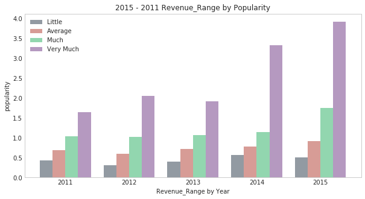

```python
# Setting the positions
pos = list(range(len(dfq2_summary.query('revenue_range =="Little"'))))
width = 0.2

#The bars and axis
fig, ax = plt.subplots(figsize=(10,5))
plt.bar(pos,
        dfq2_summary.query('revenue_range =="Little"')['popularity'],
        width,
        alpha=0.5,
        color='#273746',
        label= 'Little')

plt.bar([p + width for p in pos],
        dfq2_summary.query('revenue_range =="Average"')['popularity'],
        width,
        alpha=0.5,
        color='#B03A2E',
        label='Average')

plt.bar([p + width*2 for p in pos],
        dfq2_summary.query('revenue_range =="Much"')['popularity'],
        width,
        alpha=0.5,
        color='#27AE60',
        label='Much')

plt.bar([p + width*3 for p in pos],
        dfq2_summary.query('revenue_range =="Very Much"')['popularity'],
        width,
        alpha=0.5,
        color='#6C3483',
        label='Very Much')

ax.set_ylabel('popularity')
ax.set_xlabel('Revenue_Range by Year')
ax.set_title('2015 - 2011 Revenue_Range by Popularity')

ax.set_xticks([p + 1.5 * width for p in pos])
ax.set_xticklabels([2011,2012,2013,2014,2015])

plt.legend( loc='upper left')
plt.grid()
plt.show()
```

### QUESTION 3

To explore the distribution of revenue in different score rating levels (2011 - 2015), almost the same line of code in Question 2 will be applicable here.

```python
# Grouping the revenue_range by year and finding the vote_average mean
dfq2_summary = df_q2.groupby(['release_year','revenue_range']).mean()
dfq2_summary.tail(10)
```

| release_year | revenue_range | id | popularity | budget | revenue | runtime | vote_count | vote_average |
| --- | --- | --- | --- | --- | --- | --- | --- | --- |
| 2013 | Much | 127849.442623 | 1.182148 | 3.030536e+07 | 5.630705e+07 | 109.278689 | 743.377049 | 6.191803 |
|  | Very Much | 100778.180328 | 2.338144 | 9.780328e+07 | 3.396516e+08 | 114.934426 | 2077.311475 | 6.522951 |
| 2014 | Little | 232927.315789 | 0.658621 | 5.082375e+06 | 4.437986e+05 | 100.157895 | 149.842105 | 6.028070 |
|  | Average | 222570.719298 | 1.116157 | 1.043974e+07 | 9.737610e+06 | 105.210526 | 369.052632 | 6.245614 |
|  | Much | 201590.517857 | 1.806969 | 3.079245e+07 | 6.239669e+07 | 108.678571 | 617.035714 | 6.332143 |
|  | Very Much | 163114.192982 | 4.542607 | 9.251404e+07 | 3.553525e+08 | 115.456140 | 2056.245614 | 6.643860 |
| 2015 | Little | 288091.296296 | 0.672883 | 7.802640e+06 | 7.311892e+05 | 101.851852 | 106.592593 | 5.918519 |
|  | Average | 268269.129630 | 1.224921 | 1.779000e+07 | 1.399316e+07 | 105.092593 | 266.703704 | 6.103704 |
|  | Much | 267348.962963 | 2.017584 | 2.311923e+07 | 6.356421e+07 | 107.537037 | 684.018519 | 6.362963 |
|  | Very Much | 219819.685185 | 5.369140 | 9.754528e+07 | 4.173124e+08 | 117.703704 | 1952.944444 | 6.496296 |

Visualizations will make the question more answerable.

[figure not shown]

```python
pos = list(range(len(dfq2_summary.query('revenue_range =="Little"'))))
width = 0.2

#Setting the chart range
fig, ax = plt.subplots(figsize=(12,3))

#Chart parameters
plt.bar(pos,
        dfq2_summary.query('revenue_range =="Little"')['vote_average'],
        width,
        alpha=0.5,
        color='#DE3163',
        label= 'Low')

plt.bar([p + width for p in pos],
        dfq2_summary.query('revenue_range =="Average"')['vote_average'],
        width,
        alpha=0.5,
        color='#6495ED',
        label='Medium')

plt.bar([p + width*2 for p in pos],
        dfq2_summary.query('revenue_range =="Much"')['vote_average'],
        width,
        alpha=0.5,
        color='#DFFF00',
        label='Much')

plt.bar([p + width*3 for p in pos],
        dfq2_summary.query('revenue_range =="Very Much"')['vote_average'],
        width,
        alpha=0.5,
        color='#1C2833',
        label='Very Much')

ax.set_ylabel('vote average')
ax.set_xlabel('Revenue Range by Year')
ax.set_title('2011 - 2015 Revenue Range by Vote Average Score')

ax.set_xticks([p + 1.5 * width for p in pos])
ax.set_xticklabels([2015,2014,2013,2012,2011])

plt.ylim(2, 10)

plt.legend(loc='upper center')
plt.grid()
plt.show()
```

## Conclusions

QUESTION 2 revealed that, movies with high revenue gained more popularity with 2011 - 2015, and

QUESTION 3 shows the properties associated with increase voting score.

```python
from subprocess import call
call(['python', '-m', 'nbconvert', 'Investigate_a_Dataset.ipynb'])
```

```
255
```